# Latest Iteration of HOTR model evaluation

Michelle M. Fink

02/26/2020

Expand code block to see libraries and functions used.

```r
library(dplyr)
library(stringr)
library(randomForest)
library(lme4)
library(ROCR)
library(PresenceAbsence) # for Kappa and PCC
#library(dismo) # for response curves, but doesn't work for either glmer or rf
library(ggplot2)

getConfusionMatrix <- function(tbl) {
  #https://stats.stackexchange.com/questions/35609/why-do-i-need-bag-composition-to-calculate-oob-error-of-combined-random-forest-m/35613#35613
  class.error = vector()

  for (i in 1:nrow(tbl)) {
    rowSum = sum(tbl[i,])
    accurate = diag(tbl)[i]
    error = rowSum - accurate

    class.error[i] = error / rowSum
  }
  return(cbind(tbl, class.error))
}

opt.cut <- function(perf, pred){
  #https://www.r-bloggers.com/a-small-introduction-to-the-rocr-package/
  #calculates sensitivity = specificity threshold
  mapply(FUN=function(x, y, p){
    d = (x - 0)^2 + (y-1)^2
    ind = which(d == min(d))
    c(sensitivity = y[[ind]], specificity = 1-x[[ind]],
      cutoff = p[[ind]])
  }, perf@x.values, perf@y.values, pred@cutoffs)
}

modEval <- function(modobj, run_name, modtype='GLM'){
  if(modtype=="RF"){
    p_rf.mod <- predict(modobj, type = "prob")
    pred.mod <- prediction(p_rf.mod[,2], modobj$y)
  } else {
    pred.mod <- prediction(modobj@resp$mu, modobj@resp$y)
  }

  perf.roc <- performance(pred.mod, "tpr", "fpr")
  perf.err <- performance(pred.mod, "err")
  AUC <- performance(pred.mod, measure = "auc")@y.values[[1]]
  sst <- opt.cut(perf.roc,pred.mod)
  TSS <- sst[1] + sst[2] - 1

  if(modtype=="RF"){
    ptab_rf.mod <- table(modobj$predicted, modobj$y)
    err_rate <- 1-sum(diag(ptab_rf.mod))/sum(ptab_rf.mod)
  } else {
    err_rate <- perf.err@y.values[[1]][which(perf.err@x.values[[1]] == sst[3])]
  }

  #Presence.Absence insists on its own data structure
  padat <- data.frame(ID=seq(1:length(pred.mod@predictions[[1]])),
                    OBS=as.numeric(levels(pred.mod@labels[[1]]))[pred.mod@labels[[1]]],
                    PRED=pred.mod@predictions[[1]])

  pacmx <- cmx(padat, threshold = sst[3])
  kappa <- Kappa(pacmx, st.dev = FALSE)
  PCC <- pcc(pacmx, st.dev = FALSE)

  #plotting ROC
  #ggplot code adapted from https://davidrroberts.wordpress.com/2015/09/22/quick-auc-function-in-r-with-rocr-package/
  i <- which(perf.roc@alpha.values[[1]] == sst[3])
  plotdat <- data.frame(FP=perf.roc@x.values[[1]],TP=perf.roc@y.values[[1]])
  rocp <- ggplot(plotdat, aes(x=FP,y=TP)) +
    geom_line(lwd=2, col="red") +
    geom_abline(intercept=0,slope=1,lwd=1,lty=2,col="gray") +
    geom_point(aes(x=perf.roc@x.values[[1]][i], y=perf.roc@y.values[[1]][i]),
               pch=19, size=3, col="blue") +
    annotate("text",x=0.97,y=0.15,label=str_glue("AUC={round(AUC,3)}"),hjust=1) +
    annotate("text",x=0.97,y=0.10,label=str_glue("Threshold={round(sst[3],3)}"),hjust=1) +
    scale_x_continuous("False Positive Rate", limits=c(0,1)) +
    scale_y_continuous("True Positive Rate", limits=c(0,1)) +
    coord_fixed(ratio = 1) +
    ggtitle(paste(run_name, "ROC"))

  return(list(rocp, c(run_name, AUC, TSS, err_rate, kappa, PCC, sst[1], sst[2], sst[3]), pacmx))
}
```

# Results of the different runs

Note that most of these models are very large files and take a good bit of memory to load and time to analyze.  
This script can only realistically be run on the CNHP modeling server. The output html requires javascript to work.

Each tab displays a different aspect of model evaluation and comparison. Click on the **‘Code’** button to view the code blocks.

*Load Models:*

```r
pth <- "H:/HOTR_models/"
RF_clim <- readRDS(paste0(pth,"RF_climate_Feb24_norm.rds"))
RF_dirt <- readRDS(paste0(pth,"RF_toposoils_Feb24_norm.rds"))
RF_nlcd1 <- readRDS(paste0(pth,"RF_NLCD_onehot_Feb24_norm.rds"))
RF_nlcd2 <- readRDS(paste0(pth,"RF_NLCD_onehot_Feb24_noShrub.rds"))
RF_cd <- readRDS(paste0(pth,"RF_climdirt_Feb25_norm.rds"))
RF_all1 <- readRDS(paste0(pth,"RF_alltypes_onehot_Feb25_norm.rds"))

GLM_clim <- readRDS(paste0(pth,"GLMER_climate_Feb24_norm.rds"))
GLM_dirt <- readRDS(paste0(pth,"GLMER_toposoils_Feb24_norm.rds"))
GLM_nlcd <- readRDS(paste0(pth,"GLMER_nlcd_Feb24_norm.rds"))
GLM_cd <- readRDS(paste0(pth,"GLMER_climdirt_Feb25_norm.rds"))
GLM_all <- readRDS(paste0(pth,"GLMER_alltypes_Feb25_norm.rds"))
```

*Run each model through main evaluation function*

```r
evRF_clim <- modEval(RF_clim, "RF Climate", modtype = "RF")
evRF_dirt <- modEval(RF_dirt, "RF Topography and Soils", modtype = "RF")
evRF_nlcd1 <- modEval(RF_nlcd1, "RF NLCD One-hot, All", modtype = "RF")
evRF_nlcd2 <- modEval(RF_nlcd2, "RF NLCD One-hot, No Shrubs", modtype = "RF")
evRF_cd <- modEval(RF_cd, "RF Climate and Topo/Soils", modtype = "RF")
evRF_all1 <- modEval(RF_all1, "RF Climate, Topo/Soils, NLCD", modtype = "RF")

evGLM_clim <- modEval(GLM_clim, "GLMM Climate")
evGLM_dirt <- modEval(GLM_dirt, "GLMM Topography and Soils")
evGLM_nlcd <- modEval(GLM_nlcd, "GLMM NLCD")
evGLM_cd <- modEval(GLM_cd, "GLMM Climate and Topo/Soils")
evGLM_all <- modEval(GLM_all, "GLMM Climate, Topo/Soils, NLCD")
```

## Covariance

The graphic below shows the Covariate Correlation matrix of all of the environmental inputs that 1) were used in these models and 2) would fit within the function. (meaning; not everything is shown but I did my best)

The output is independent of any model, and shows:

- left-hand edge: percent deviance explained when run in a GLM (or GAM, depending on convergence)
- top edge: the number of correlations higher than 0.7 between this input and all the others in the matrix
- left-most graph: response curve, with lower rug=absence points, upper rug=presence points
- diagonal graph: histogram distribution of the input, titled with the name of the input
- above diagonal: the greater of the Pearson, Spearman, or Kendall pairwise correlation between the row input and the column input
- below diagonal: pairwise scatterplot of the row input and the column input (red=presence, blue=absence)

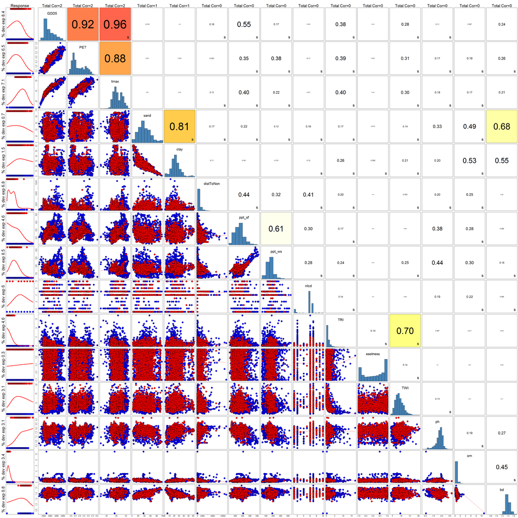

Generated by VisTrails SAHM

## ROC Plots

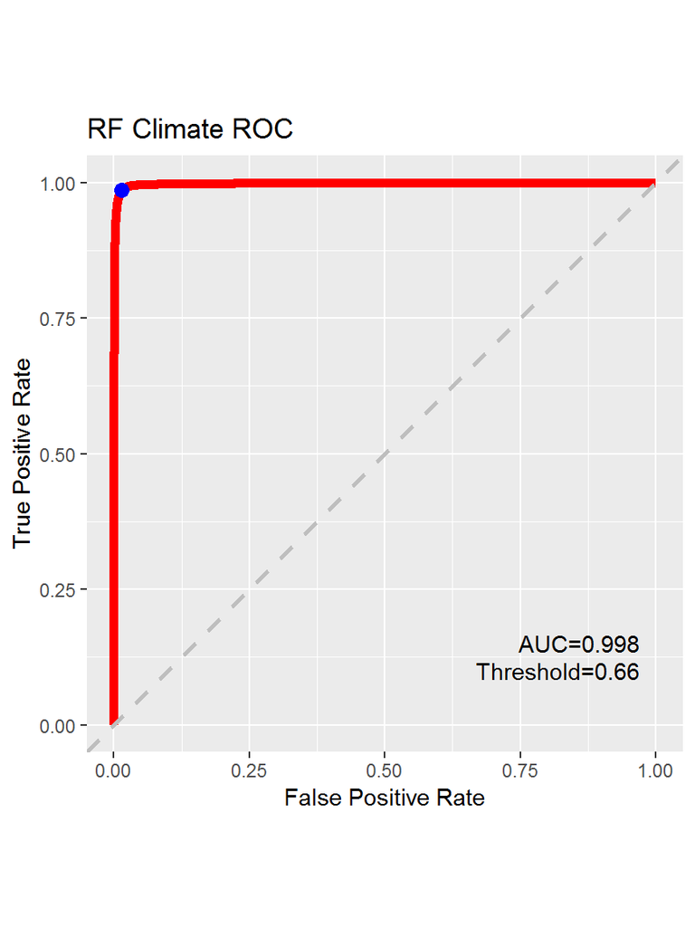

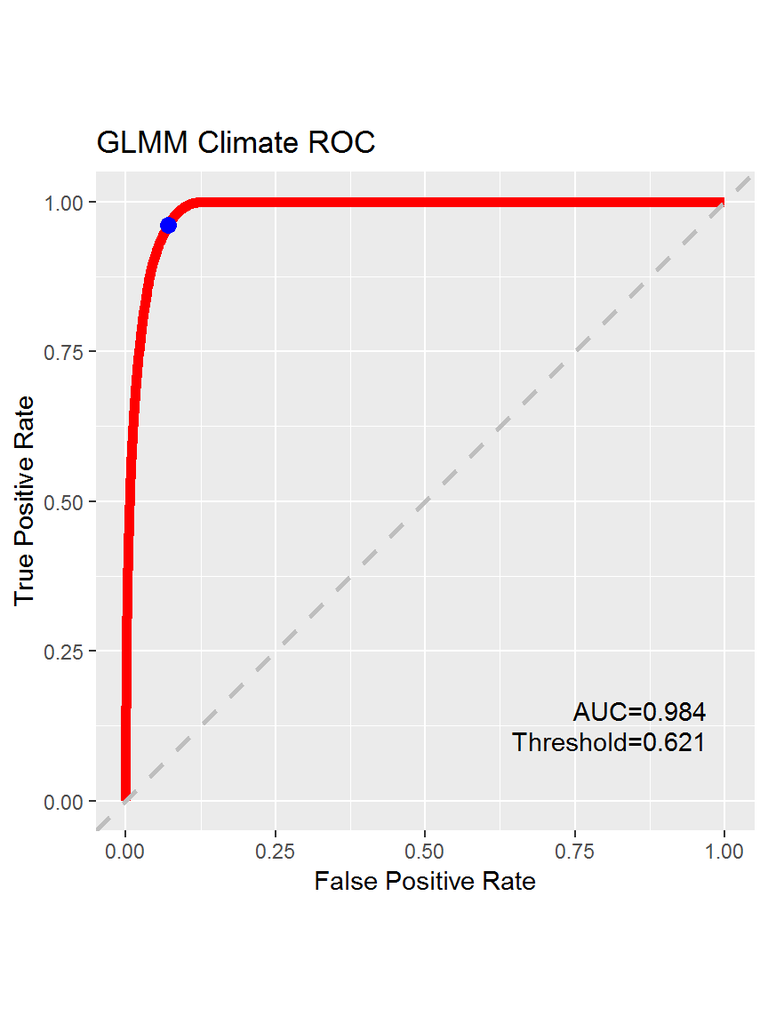

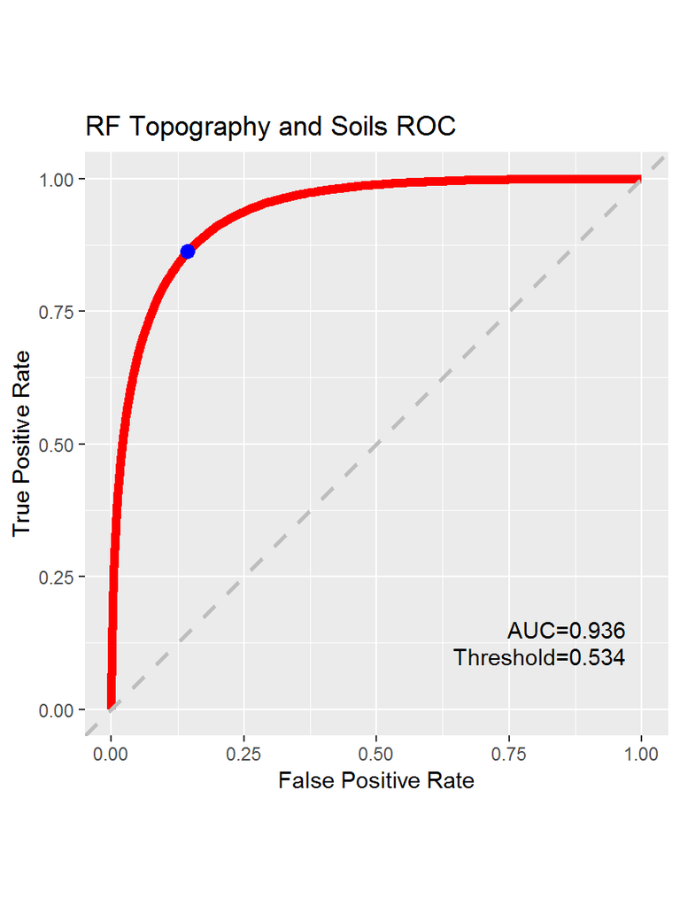

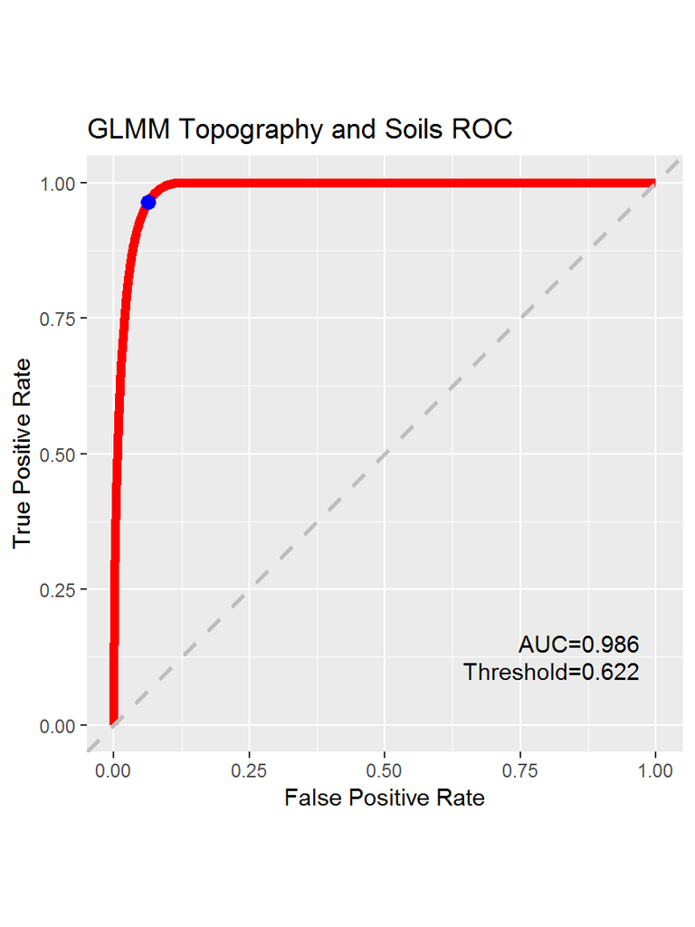

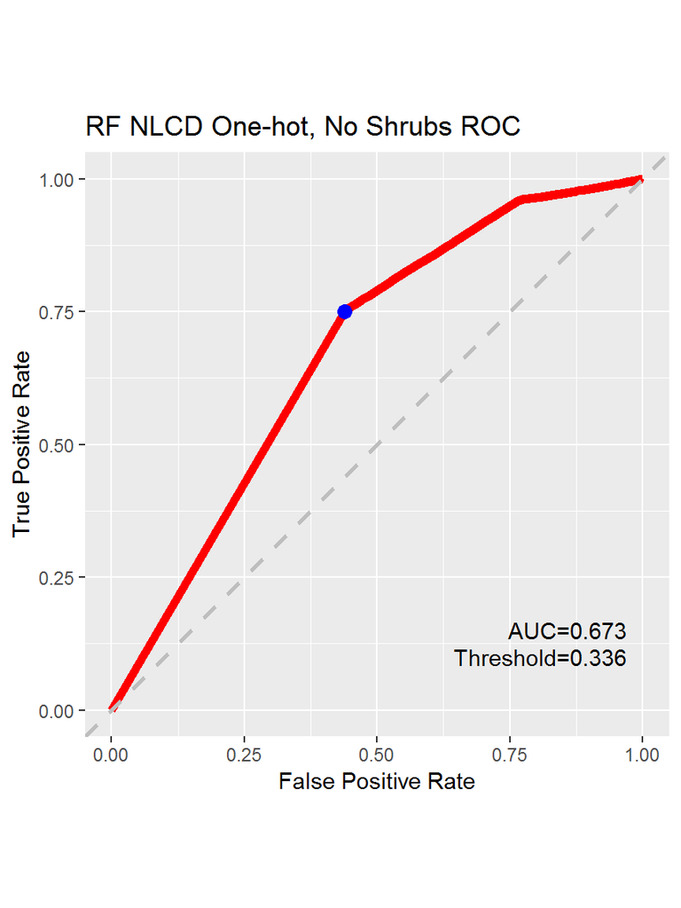

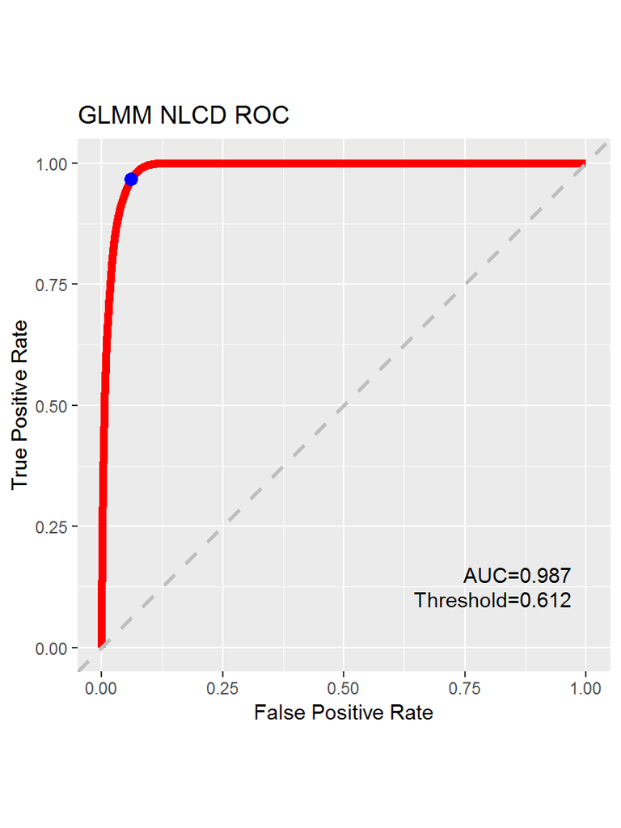

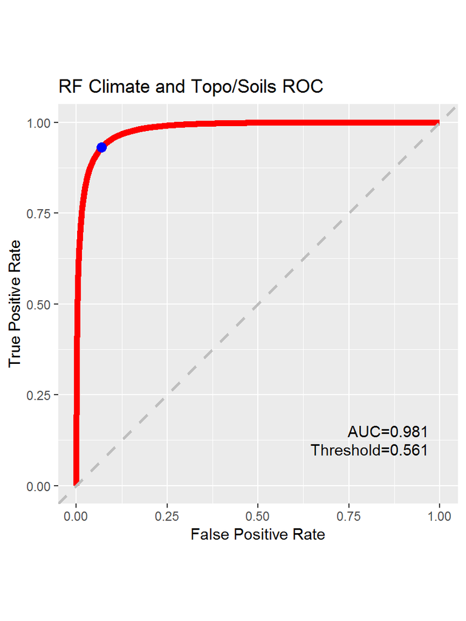

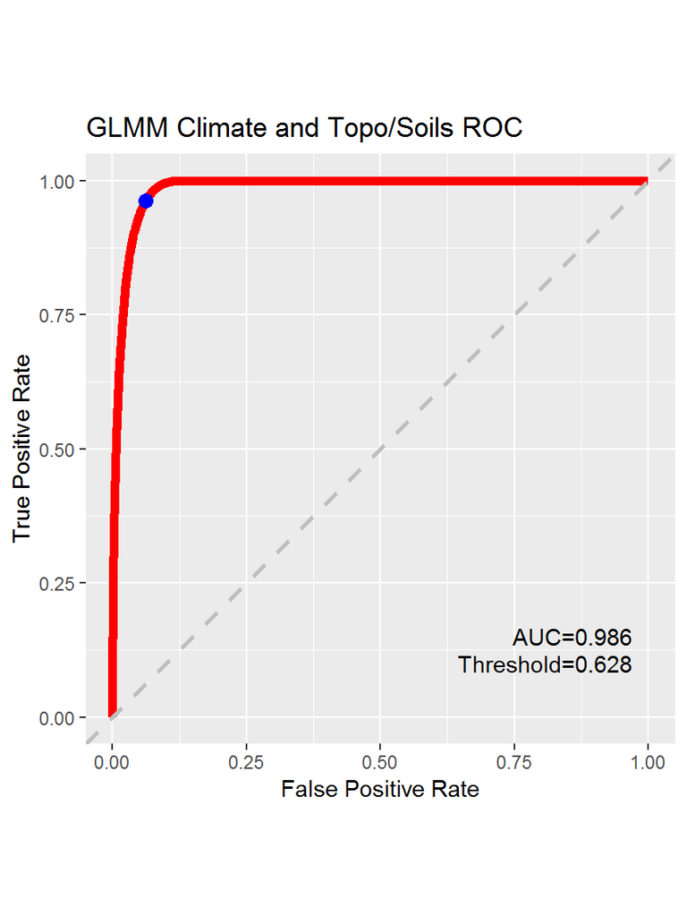

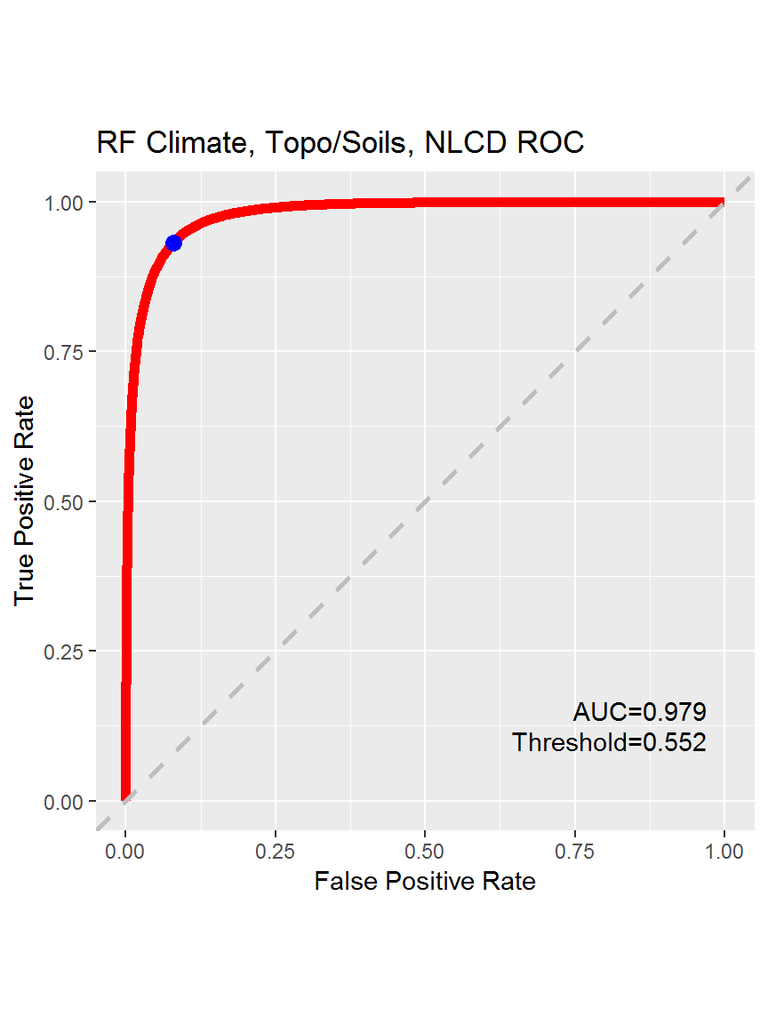

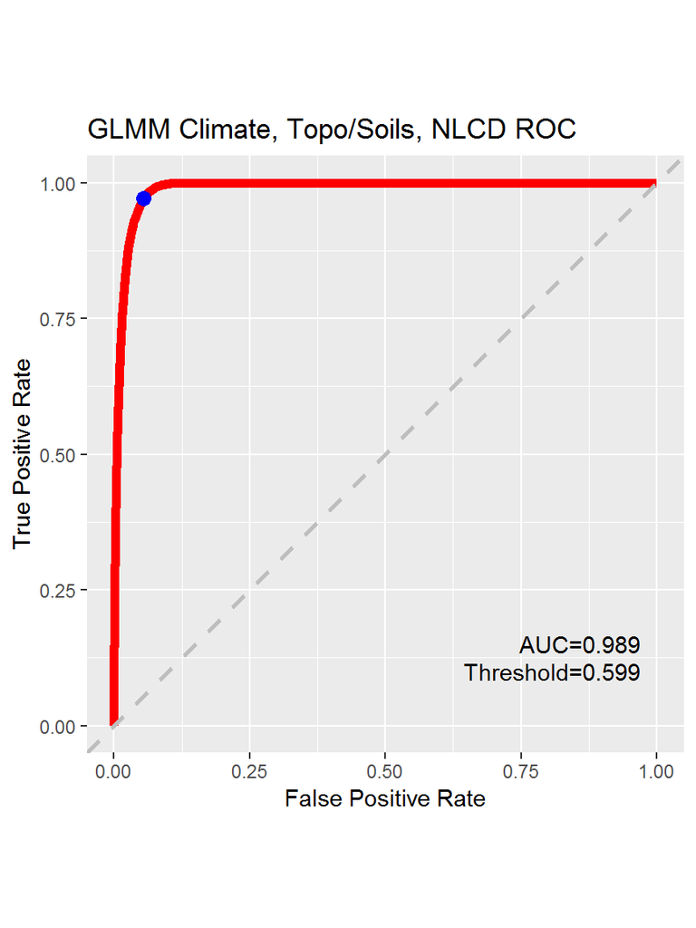

```r
evRF_clim[1]
evGLM_clim[1]

evRF_dirt[1]
evGLM_dirt[1]

#evRF_nlcd1[1] #to keep the figs in pairs
evRF_nlcd2[1]
evGLM_nlcd[1]

evRF_cd[1]
evGLM_cd[1]

evRF_all1[1]
evGLM_all[1]
## [[1]]
##
## [[1]]
##
## [[1]]
##
## [[1]]
##
## [[1]]
##
## [[1]]
##
## [[1]]
##
## [[1]]
##
## [[1]]
##
## [[1]]
```

## Evaluation Metrics

```r
kable(outdf, format = "html", row.names = FALSE, digits = 3) %>%
  kable_styling(bootstrap_options = c("striped", "hover", "condensed", "responsive")) %>%
  column_spec(2:9, color="black") %>% column_spec(1, bold=TRUE)
```

| Model | AUC | TSS | Error_Rate | Kappa | PCC | Sensitivity | Specificity | Threshold |
| --- | --- | --- | --- | --- | --- | --- | --- | --- |
| RF Climate | 0.998 | 0.971 | 0.017 | 0.971 | 0.986 | 0.986 | 0.986 | 0.660 |
| GLMM Climate | 0.984 | 0.891 | 0.055 | 0.891 | 0.945 | 0.961 | 0.930 | 0.621 |
| RF Topography and Soils | 0.936 | 0.719 | 0.141 | 0.719 | 0.859 | 0.863 | 0.856 | 0.534 |
| GLMM Topography and Soils | 0.986 | 0.901 | 0.049 | 0.901 | 0.951 | 0.964 | 0.937 | 0.622 |
| RF NLCD One-hot, All | 0.658 | 0.311 | 0.345 | 0.000 | 0.500 | 0.750 | 0.561 | 1.000 |
| RF NLCD One-hot, No Shrubs | 0.673 | 0.311 | 0.345 | 0.311 | 0.655 | 0.750 | 0.561 | 0.336 |
| GLMM NLCD | 0.987 | 0.906 | 0.047 | 0.906 | 0.953 | 0.967 | 0.939 | 0.612 |
| RF Climate and Topo/Soils | 0.981 | 0.862 | 0.071 | 0.862 | 0.931 | 0.931 | 0.931 | 0.561 |
| GLMM Climate and Topo/Soils | 0.986 | 0.901 | 0.050 | 0.901 | 0.950 | 0.963 | 0.938 | 0.628 |
| RF Climate, Topo/Soils, NLCD | 0.979 | 0.852 | 0.075 | 0.852 | 0.926 | 0.932 | 0.921 | 0.552 |
| GLMM Climate, Topo/Soils, NLCD | 0.989 | 0.916 | 0.042 | 0.916 | 0.958 | 0.971 | 0.946 | 0.599 |

## Variable Importance

### 1) Climate Variables

#### Random Forest

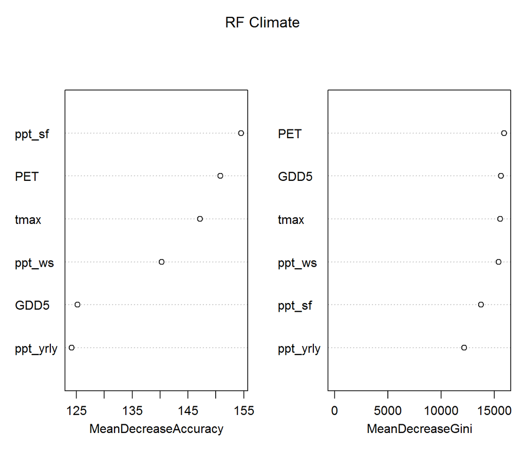

```r
varImpPlot(RF_clim, main = evRF_clim[[2]][1])
```

```r
ptab_rf <- table(RF_clim$predicted, RF_clim$y)

print("Confusion Matrix")
getConfusionMatrix(ptab_rf)
```

```
## [1] "Confusion Matrix"
##       0     1 class.error
## 0 85959   596 0.006885795
## 1  2343 87706 0.026019167
```

#### GLMM

```r
summary(GLM_clim)

print("Confusion Matrix")
evGLM_clim[3]
```

```
## Generalized linear mixed model fit by maximum likelihood (Adaptive
##   Gauss-Hermite Quadrature, nAGQ = 0) [glmerMod]
##  Family: binomial  ( logit )
## Formula: response ~ 1 + GDD5 + PET + ppt_sf + ppt_ws + ppt_yrly + tmax +
##     (1 | Grid_ID)
##    Data: indata
## Control: glmerControl(optimizer = "bobyqa")
##
##      AIC      BIC   logLik deviance df.resid
##  68071.4  68141.9 -34028.7  68057.4   176597
##
## Scaled residuals:
##      Min       1Q   Median       3Q      Max
## -24.5357  -0.0740   0.0082   0.1966   3.7028
##
## Random effects:
##  Groups  Name        Variance Std.Dev.
##  Grid_ID (Intercept) 24.28    4.927
## Number of obs: 176604, groups:  Grid_ID, 15185
##
## Fixed effects:
##             Estimate Std. Error z value Pr(>|z|)
## (Intercept)  -45.481      2.077 -21.896  < 2e-16 ***
## GDD5         -46.024      2.273 -20.245  < 2e-16 ***
## PET           13.059      1.582   8.253  < 2e-16 ***
## ppt_sf        -1.412      1.050  -1.345    0.179
## ppt_ws         9.303      2.062   4.511 6.47e-06 ***
## tmax          67.425      3.315  20.338  < 2e-16 ***
## ---
## Signif. codes:  0 '***' 0.001 '**' 0.01 '*' 0.05 '.' 0.1 ' ' 1
##
## Correlation of Fixed Effects:
##        (Intr) GDD5   PET    ppt_sf ppt_ws
## GDD5    0.859
## PET    -0.336 -0.635
## ppt_sf -0.054 -0.181 -0.133
## ppt_ws -0.259 -0.245  0.538 -0.717
## tmax   -0.958 -0.772  0.090  0.105  0.076
## fit warnings:
## fixed-effect model matrix is rank deficient so dropping 1 column / coefficient
## [1] "Confusion Matrix"
## [[1]]
##          observed
## predicted     1     0
##         1 84854  6209
##         0  3448 82093
```

**Note:** the coefficient that got dropped is *ppt_yrly*, which I wouldn’t normally include anyway.  
Also, for the GLMM models, the confusion matrix is computed at the *Sensitivity=Specificity* Threshold. This does not apply to Random Forest model confusion matrices.

### 2) Topography and Soils

#### Random Forest

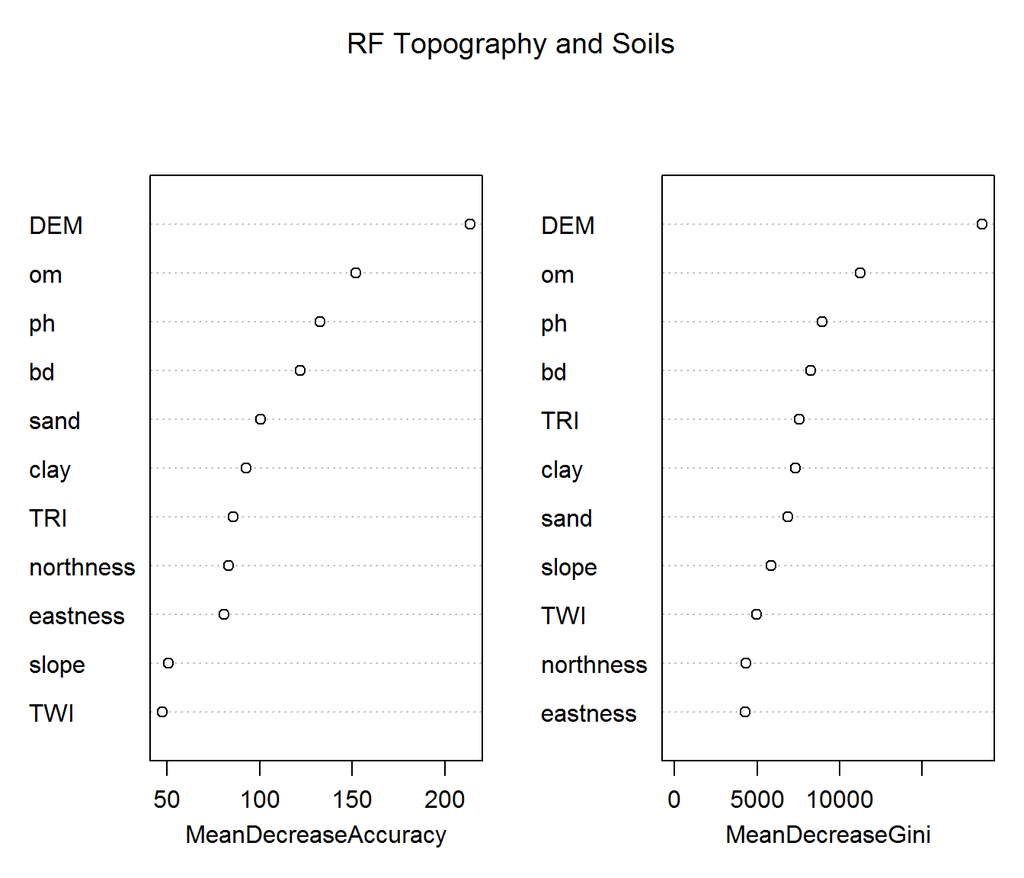

```r
varImpPlot(RF_dirt, main = evRF_dirt[[2]][1])
```

```r
ptab_rf <- table(RF_dirt$predicted, RF_dirt$y)

print("Confusion Matrix")
getConfusionMatrix(ptab_rf)
```

```
## [1] "Confusion Matrix"
##       0     1 class.error
## 0 73576 10207   0.1218266
## 1 14726 78095   0.1586494
```

#### GLMM

```r
summary(GLM_dirt)

print("Confusion Matrix")
evGLM_dirt[3]
```

```
## Generalized linear mixed model fit by maximum likelihood (Adaptive
##   Gauss-Hermite Quadrature, nAGQ = 0) [glmerMod]
##  Family: binomial  ( logit )
## Formula: response ~ 1 + bd + clay + DEM + eastness + northness + om +
##     ph + sand + slope + TRI + TWI + (1 | Grid_ID)
##    Data: indata
## Control: glmerControl(optimizer = "bobyqa")
##
##      AIC      BIC   logLik deviance df.resid
##  66595.5  66726.5 -33284.7  66569.5   176591
##
## Scaled residuals:
##      Min       1Q   Median       3Q      Max
## -28.4019  -0.0776   0.0040   0.1846  15.4262
##
## Random effects:
##  Groups  Name        Variance Std.Dev.
##  Grid_ID (Intercept) 26.83    5.18
## Number of obs: 176604, groups:  Grid_ID, 15185
##
## Fixed effects:
##               Estimate Std. Error z value Pr(>|z|)
## (Intercept)   -6.91546    0.46466 -14.883  < 2e-16 ***
## bd             1.15128    0.43536   2.644  0.00818 **
## clay           2.10709    0.25472   8.272  < 2e-16 ***
## DEM            5.22998    0.55843   9.365  < 2e-16 ***
## eastness      -0.09750    0.01936  -5.037 4.72e-07 ***
## northness     -0.11522    0.02040  -5.648 1.62e-08 ***
## om             2.33709    4.83532   0.483  0.62886
## ph             2.31581    0.30172   7.675 1.65e-14 ***
## sand          -0.32406    0.21764  -1.489  0.13650
## slope        -43.84766    6.56157  -6.682 2.35e-11 ***
## TRI         -103.64654    5.82630 -17.789  < 2e-16 ***
## TWI           -2.53037    0.23056 -10.975  < 2e-16 ***
## ---
## Signif. codes:  0 '***' 0.001 '**' 0.01 '*' 0.05 '.' 0.1 ' ' 1
##
## Correlation of Fixed Effects:
##           (Intr) bd     clay   DEM    estnss nrthns om     ph     sand   slope
## bd        -0.718
```

[output cut: 13 more lines]

```
## DEM
## eastness
## northness
## om
## ph
## sand
## slope
## TRI
## TWI       -0.186
## [1] "Confusion Matrix"
## [[1]]
##          observed
## predicted     1     0
##         1 85105  5537
##         0  3197 82765
```

### 3) Land Use

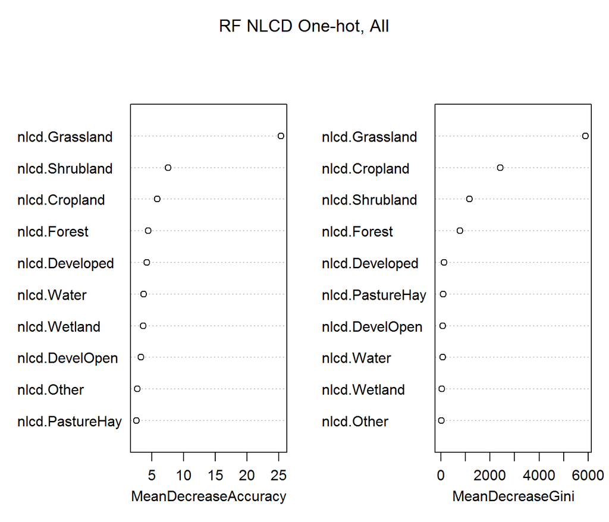

```r
varImpPlot(RF_nlcd1, main = evRF_nlcd1[[2]][1])
```

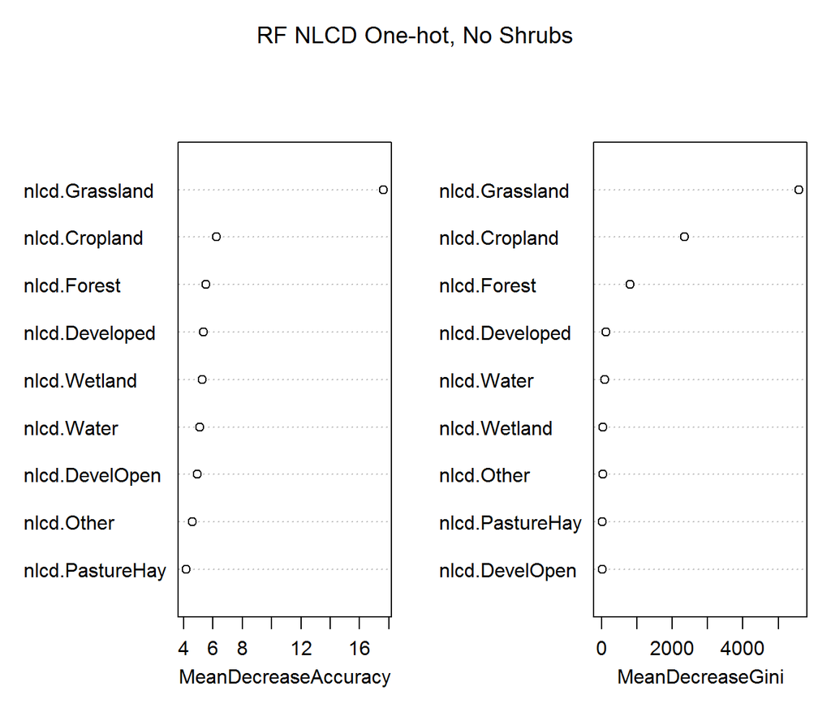

```r
varImpPlot(RF_nlcd2, main = evRF_nlcd2[[2]][1])
```

```r
ptab_rf1 <- table(RF_nlcd1$predicted, RF_nlcd1$y)
ptab_rf2 <- table(RF_nlcd2$predicted, RF_nlcd2$y)

print(paste("Confusion Matrix", evRF_nlcd1[[2]][1]))
getConfusionMatrix(ptab_rf1)

print(paste("Confusion Matrix", evRF_nlcd2[[2]][1]))
getConfusionMatrix(ptab_rf2)
```

```
## [1] "Confusion Matrix RF NLCD One-hot, All"
##       0     1 class.error
## 0 49537 22102   0.3085191
## 1 38765 66200   0.3693136
## [1] "Confusion Matrix RF NLCD One-hot, No Shrubs"
##       0     1 class.error
## 0 49537 22102   0.3085191
## 1 38765 66200   0.3693136
```

#### GLMM

```r
summary(GLM_nlcd)

print("Confusion Matrix")
evGLM_nlcd[3]
```

```
## Generalized linear mixed model fit by maximum likelihood (Adaptive
##   Gauss-Hermite Quadrature, nAGQ = 0) [glmerMod]
##  Family: binomial  ( logit )
## Formula: response ~ 1 + nlcd.Cropland + nlcd.Developed + nlcd.DevelOpen +
##     nlcd.Forest + nlcd.Grassland + nlcd.Other + nlcd.PastureHay +
##     nlcd.Water + nlcd.Wetland + (1 | Grid_ID)
##    Data: indata
## Control: glmerControl(optimizer = "bobyqa")
##
##      AIC      BIC   logLik deviance df.resid
##  64949.2  65060.1 -32463.6  64927.2   176593
##
## Scaled residuals:
##     Min      1Q  Median      3Q     Max
## -37.928  -0.077   0.003   0.172  14.602
##
## Random effects:
##  Groups  Name        Variance Std.Dev.
##  Grid_ID (Intercept) 27.37    5.232
## Number of obs: 176604, groups:  Grid_ID, 15185
##
## Fixed effects:
##                 Estimate Std. Error z value Pr(>|z|)
## (Intercept)     -4.50295    0.06597 -68.258  < 2e-16 ***
## nlcd.Cropland   -2.22111    0.07157 -31.035  < 2e-16 ***
## nlcd.Developed  -3.38372    0.28698 -11.791  < 2e-16 ***
## nlcd.DevelOpen  -0.74103    0.12274  -6.037 1.57e-09 ***
## nlcd.Forest     -3.01186    0.23426 -12.857  < 2e-16 ***
## nlcd.Grassland   1.13166    0.04223  26.795  < 2e-16 ***
## nlcd.Other      -1.51195    0.26811  -5.639 1.71e-08 ***
## nlcd.PastureHay -0.34259    0.17174  -1.995   0.0461 *
## nlcd.Water      -2.16017    0.34345  -6.290 3.18e-10 ***
## nlcd.Wetland    -1.12076    0.17786  -6.301 2.95e-10 ***
## ---
## Signif. codes:  0 '***' 0.001 '**' 0.01 '*' 0.05 '.' 0.1 ' ' 1
##
## Correlation of Fixed Effects:
##             (Intr) nlcd.C nlcd.D nlc.DO nlcd.F nlcd.G nlcd.O nlc.PH nlcd.Wtr
## nlcd.Crplnd -0.273
## nlcd.Devlpd -0.062  0.101
## nlcd.DvlOpn -0.146  0.196  0.131
## nlcd.Forest -0.068  0.089  0.019  0.038
## nlcd.Grssln -0.472  0.474  0.109  0.263  0.116
## nlcd.Other  -0.073  0.076  0.017  0.041  0.020  0.142
## nlcd.PstrHy -0.123  0.183  0.037  0.083  0.044  0.211  0.040
## nlcd.Water  -0.055  0.077  0.023  0.037  0.017  0.099  0.015  0.027
## nlcd.Wetlnd -0.099  0.121  0.030  0.060  0.061  0.183  0.032  0.058  0.063
## [1] "Confusion Matrix"
## [[1]]
##          observed
## predicted     1     0
##         1 85351  5388
##         0  2951 82914
```

### 4) Climate + Topo/Soils + Interactions (for GLMM anyway)

#### Random Forest

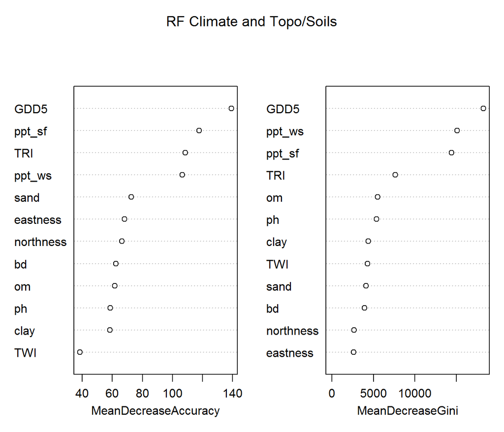

```r
varImpPlot(RF_cd, main = evRF_cd[[2]][1])
```

```r
ptab_rf <- table(RF_cd$predicted, RF_cd$y)

print("Confusion Matrix")
getConfusionMatrix(ptab_rf)
```

```
## [1] "Confusion Matrix"
##       0     1 class.error
## 0 80152  4379  0.05180348
## 1  8150 83923  0.08851672
```

#### GLMM

```r
summary(GLM_cd)
```

[output not shown]

```r
print("Confusion Matrix")
evGLM_cd[3]
```

[output not shown]

### 5) Climate + Topo/Soils + Land Use + Interactions

#### Random Forest

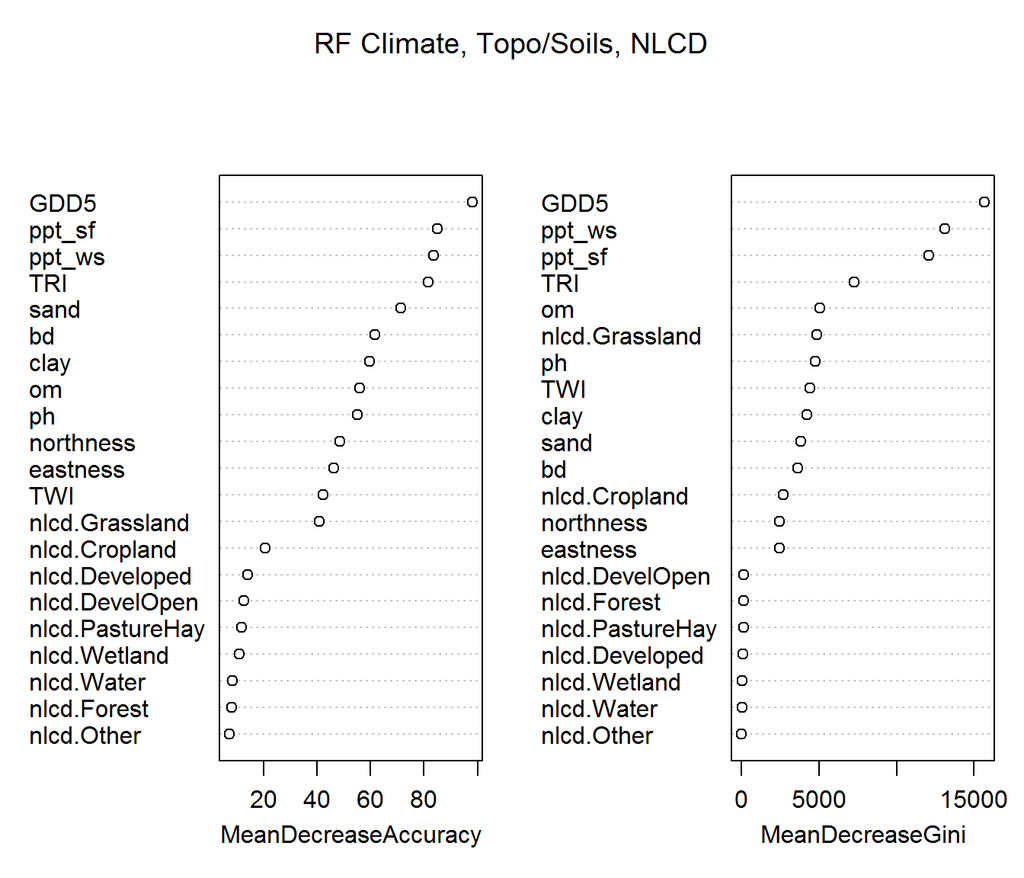

```r
varImpPlot(RF_all1, main = evRF_all1[[2]][1])
```

```r
ptab_rf <- table(RF_all1$predicted, RF_all1$y)

print("Confusion Matrix")
getConfusionMatrix(ptab_rf)
```

```
## [1] "Confusion Matrix"
##       0     1 class.error
## 0 79614  4501  0.05351008
## 1  8688 83801  0.09393550
```

#### GLMM

```r
summary(GLM_all)
```

[output not shown]

```r
print("Confusion Matrix")
evGLM_all[3]
```

[output not shown]

I was going to run another RF that used the *as.factor(NLCD)* input instead of the one-hot variables, but ran out of time. This stuff takes forever to run.